# DATA 621 - Group Assignment 3: Logistic Regression on Crime Rates

(Group 4) Mohamed Hassan-El Serafi, Chun Shing Leung, Keith Colella, Yina, Qiao, Eddie Xu

2024-10-30

## Assignment Overview

*In this homework assignment, you will explore, analyze and model a data set containing information on crime for various neighborhoods of a major city. Each record has a response variable indicating whether or not the crime rate is above the median crime rate (1) or not (0).*

## Data Exploration

*Describe the size and the variables in the crime training data set. Consider that too much detail will cause a manager to lose interest while too little detail will make the manager consider that you aren’t doing your job.*

```r
# pull in the training data set
crime_training_data <- read.csv("https://raw.githubusercontent.com/eddiexunyc/crime_binary_logistic_regression/refs/heads/main/Resources/crime-training-data_modified.csv")

# pull in the test data
crime_test_data <- read.csv("https://raw.githubusercontent.com/eddiexunyc/crime_binary_logistic_regression/refs/heads/main/Resources/crime-evaluation-data_modified.csv")

glimpse(crime_training_data)
```

```
## Rows: 466
## Columns: 13
## $ zn      <dbl> 0, 0, 0, 30, 0, 0, 0, 0, 0, 80, 22, 0, 0, 22, 0, 0, 100, 20, 0…
## $ indus   <dbl> 19.58, 19.58, 18.10, 4.93, 2.46, 8.56, 18.10, 18.10, 5.19, 3.6…
## $ chas    <int> 0, 1, 0, 0, 0, 0, 0, 0, 0, 0, 0, 0, 0, 0, 0, 0, 0, 0, 0, 0, 0,…
## $ nox     <dbl> 0.605, 0.871, 0.740, 0.428, 0.488, 0.520, 0.693, 0.693, 0.515,…
## $ rm      <dbl> 7.929, 5.403, 6.485, 6.393, 7.155, 6.781, 5.453, 4.519, 6.316,…
## $ age     <dbl> 96.2, 100.0, 100.0, 7.8, 92.2, 71.3, 100.0, 100.0, 38.1, 19.1,…
## $ dis     <dbl> 2.0459, 1.3216, 1.9784, 7.0355, 2.7006, 2.8561, 1.4896, 1.6582…
## $ rad     <int> 5, 5, 24, 6, 3, 5, 24, 24, 5, 1, 7, 5, 24, 7, 3, 3, 5, 5, 24, …
## $ tax     <int> 403, 403, 666, 300, 193, 384, 666, 666, 224, 315, 330, 398, 66…
## $ ptratio <dbl> 14.7, 14.7, 20.2, 16.6, 17.8, 20.9, 20.2, 20.2, 20.2, 16.4, 19…
## $ lstat   <dbl> 3.70, 26.82, 18.85, 5.19, 4.82, 7.67, 30.59, 36.98, 5.68, 9.25…
## $ medv    <dbl> 50.0, 13.4, 15.4, 23.7, 37.9, 26.5, 5.0, 7.0, 22.2, 20.9, 24.8…
## $ target  <int> 1, 1, 1, 0, 0, 0, 1, 1, 0, 0, 0, 0, 1, 1, 0, 0, 0, 1, 1, 1, 0,…
```

### Exploratory Data Analysis

A simple exploratory data analysis will be conducted and the training data provided will be used to determine the property and value of the dataset. The `DataExplorer` package will be used to provide a full profile for the data frame.

With the data set given, there are 466 rows, 13 columns and 6058 observations. There is no missing values or observations and all columns have continuous values. The `chas` variable is the only dummy variable out of 13 columns and is used to determine if the suburb borders the Charles River. Based on the histograms, both `rm` and `medv` variables are normally distributed, while other variables are skewed. Both `tax` and `rad` variables have very high outliers. That could be a data quality issue.

```r
introduce(crime_training_data)
```

```
##   rows columns discrete_columns continuous_columns all_missing_columns
## 1  466      13                0                 13                   0
##   total_missing_values complete_rows total_observations memory_usage
## 1                    0           466               6058        44440
```

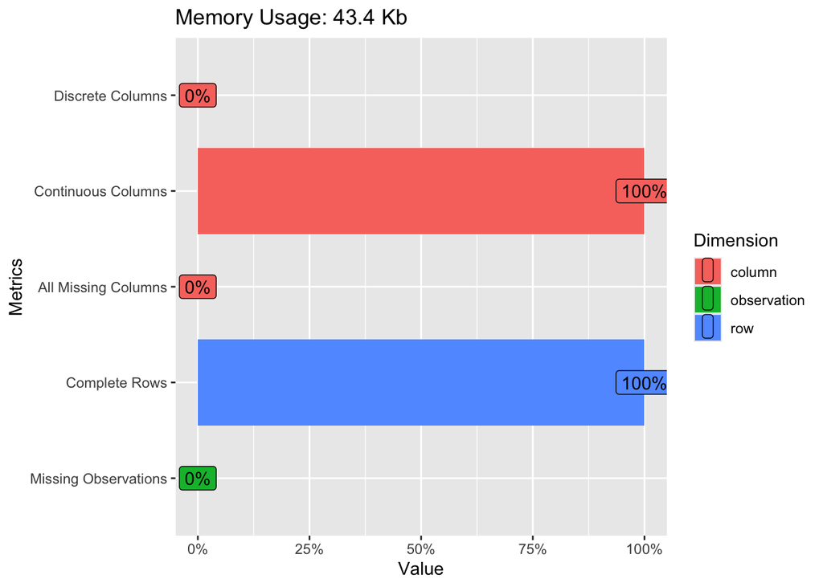

```r
# par on plots
par(mfrow = c(1, 4))
plot_intro(crime_training_data)
```

```r
describeBy(crime_training_data)
```

```
##         vars   n   mean     sd median trimmed    mad    min    max  range  skew
## zn         1 466  11.58  23.36   0.00    5.35   0.00   0.00 100.00 100.00  2.18
## indus      2 466  11.11   6.85   9.69   10.91   9.34   0.46  27.74  27.28  0.29
## chas       3 466   0.07   0.26   0.00    0.00   0.00   0.00   1.00   1.00  3.34
## nox        4 466   0.55   0.12   0.54    0.54   0.13   0.39   0.87   0.48  0.75
## rm         5 466   6.29   0.70   6.21    6.26   0.52   3.86   8.78   4.92  0.48
## age        6 466  68.37  28.32  77.15   70.96  30.02   2.90 100.00  97.10 -0.58
## dis        7 466   3.80   2.11   3.19    3.54   1.91   1.13  12.13  11.00  1.00
## rad        8 466   9.53   8.69   5.00    8.70   1.48   1.00  24.00  23.00  1.01
## tax        9 466 409.50 167.90 334.50  401.51 104.52 187.00 711.00 524.00  0.66
## ptratio   10 466  18.40   2.20  18.90   18.60   1.93  12.60  22.00   9.40 -0.75
## lstat     11 466  12.63   7.10  11.35   11.88   7.07   1.73  37.97  36.24  0.91
## medv      12 466  22.59   9.24  21.20   21.63   6.00   5.00  50.00  45.00  1.08
## target    13 466   0.49   0.50   0.00    0.49   0.00   0.00   1.00   1.00  0.03
##         kurtosis   se
## zn          3.81 1.08
## indus      -1.24 0.32
## chas        9.15 0.01
## nox        -0.04 0.01
## rm          1.54 0.03
## age        -1.01 1.31
## dis         0.47 0.10
## rad        -0.86 0.40
## tax        -1.15 7.78
## ptratio    -0.40 0.10
## lstat       0.50 0.33
## medv        1.37 0.43
## target     -2.00 0.02
```

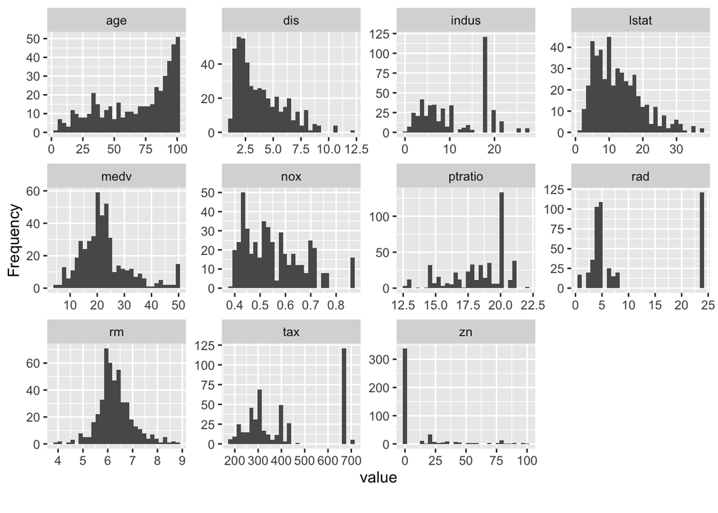

```r
plot_histogram(crime_training_data)
```

Given the box plot below, the variable `chas` has few outliers and the median is close to 0. Not only that, many variables including `dis`, `age`, `lstat`, `tax` and `rad` are skewed.

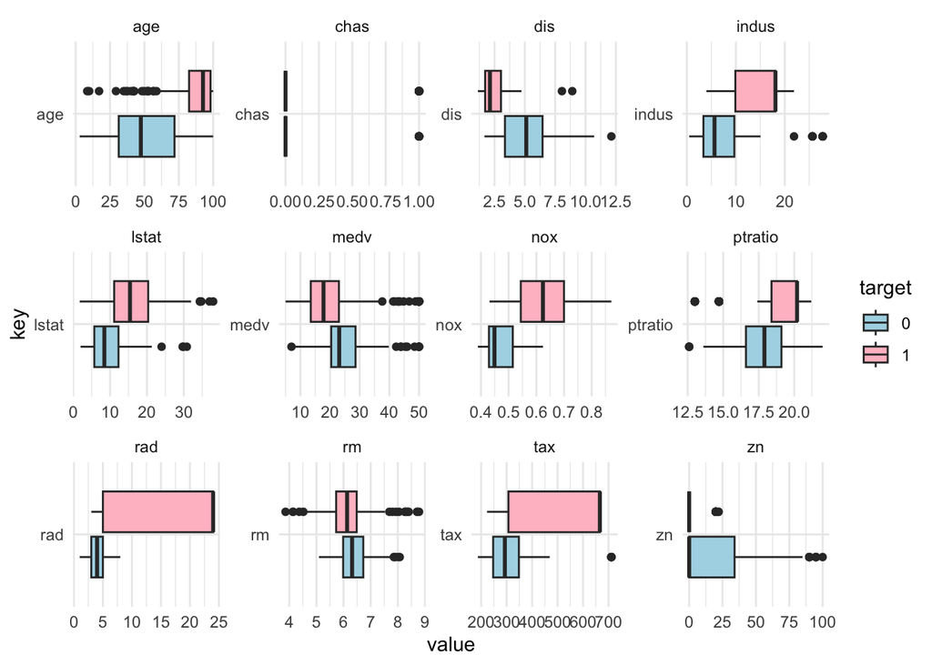

```r
# boxplot on variables
crime_box_plot <- crime_training_data %>%
  gather(key, value, -target) %>%
  mutate(key = factor(key),
         target = factor(target)) %>%
  ggplot(aes(x = key, y = value)) +
  geom_boxplot(aes(fill = target)) +
  facet_wrap(~ key, scales = 'free', ncol = 4) +
  scale_fill_manual(values=c("lightblue", "pink")) +
  coord_flip() +
  theme_minimal()

# correlation plot on variables
par(mfrow = c(1,2))
crime_box_plot
```

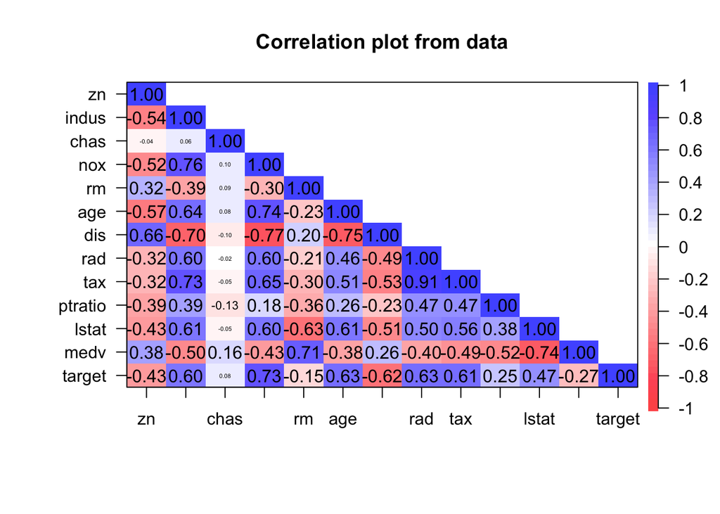

```r
corPlot(crime_training_data, upper = FALSE)
```

To determine if the dataset is compatible with the binary logistic regression model, the model is fitted and the VIF score analysis is conducted to check for any multicollinearity.

```r
# fit a linear regression before VIF score
vif_model_all <- lm(target ~ ., data = crime_training_data)

summary(vif_model_all)
```

```
##
## Call:
## lm(formula = target ~ ., data = crime_training_data)
##
## Residuals:
##      Min       1Q   Median       3Q      Max
## -0.59701 -0.21505 -0.04691  0.14908  0.88702
##
## Coefficients:
##               Estimate Std. Error t value Pr(>|t|)
## (Intercept) -1.6013725  0.3594901  -4.455 1.06e-05 ***
## zn          -0.0009668  0.0009442  -1.024 0.306432
## indus        0.0031277  0.0042909   0.729 0.466433
## chas         0.0059892  0.0588402   0.102 0.918970
## nox          1.9722476  0.2632648   7.491 3.60e-13 ***
## rm           0.0249823  0.0315042   0.793 0.428202
## age          0.0031738  0.0009045   3.509 0.000495 ***
## dis          0.0125382  0.0141433   0.887 0.375814
## rad          0.0207000  0.0043384   4.771 2.47e-06 ***
## tax         -0.0002787  0.0002617  -1.065 0.287396
## ptratio      0.0115287  0.0093460   1.234 0.218013
## lstat        0.0045124  0.0038923   1.159 0.246935
## medv         0.0089246  0.0029992   2.976 0.003080 **
## ---
## Signif. codes:  0 '***' 0.001 '**' 0.01 '*' 0.05 '.' 0.1 ' ' 1
##
## Residual standard error: 0.312 on 453 degrees of freedom
## Multiple R-squared:  0.6213, Adjusted R-squared:  0.6112
## F-statistic: 61.92 on 12 and 453 DF,  p-value: < 2.2e-16
```

After the model fitting, the P-value is less than 0.05, showing that predictor variables may be significantly associated with the outcome. There are variables in the data set with moderate correlation between predictor variables.

```r
# perform VIF
vif_value = vif(vif_model_all)
vif_value
```

```
##       zn    indus     chas      nox       rm      age      dis      rad
## 2.324259 4.120699 1.090265 4.505049 2.354788 3.134015 4.240618 6.781354
##      tax  ptratio    lstat     medv
## 9.217228 2.013109 3.649059 3.667370
```

Both `rad` and `tax` variables have the highest VIF scores and it is over 5, showing that they are severely correlated with other predictor variables. Therefore, either variable need to removed and need to reevaluated before modeling the binary regression model.

```r
# tax removed
crime_training_data_tax_removed <- crime_training_data %>%
  dplyr::select(-c(tax))
vif_model_tax <- lm(target ~., data = crime_training_data_tax_removed)
vif2_score <- vif(vif_model_tax)

# rad removed
crime_training_data_rad_removed <- crime_training_data %>%
  dplyr::select(-c(rad))
vif_model_rad <- lm(target ~., data = crime_training_data_rad_removed)
vif3_score <- vif(vif_model_rad)

# print score
vif2_score
```

```
##       zn    indus     chas      nox       rm      age      dis      rad
## 2.176933 3.244122 1.076496 4.501638 2.354781 3.129684 4.239168 2.229973
##  ptratio    lstat     medv
## 2.010186 3.641463 3.591775
```

```r
vif3_score
```

```
##       zn    indus     chas      nox       rm      age      dis      tax
## 2.294207 3.735846 1.084129 4.384975 2.326263 3.109049 4.240391 3.030983
##  ptratio    lstat     medv
## 1.921899 3.569560 3.596930
```

With either `rad` or `tax` variables removed from the data set, the updated data set is reevaluated and with the updated VIF score, both variable score dropped below 5 and it appears that `tax` variable have a bigger impact. Therefore, the data set with `tax` removed will be selected for the model building.

## Data Preparation

*Describe how you have transformed the data by changing the original variables or creating new variables. If you did transform the data or create new variables, discuss why you did this.*

```r
# perform a log transformation on rad and dis variables
crime_training_data_transformed <- crime_training_data %>%
  mutate(log(crime_training_data$age + 1),
         log(crime_training_data$dis + 1),
         log(crime_training_data$lstat + 1))
```

Since `tax` and `rad` variables have outliers, those outliers will be removed given that they might be a data quality issue. Since there is no additional information about these outliers, they are considered to be removed.

```r
# remove the skewed variables
crime_training_data_updated <- crime_training_data %>%
  filter(crime_training_data$rad != 24)

head(crime_training_data_updated)
```

```
##   zn indus chas   nox    rm   age    dis rad tax ptratio lstat medv target
## 1  0 19.58    0 0.605 7.929  96.2 2.0459   5 403    14.7  3.70 50.0      1
## 2  0 19.58    1 0.871 5.403 100.0 1.3216   5 403    14.7 26.82 13.4      1
## 3 30  4.93    0 0.428 6.393   7.8 7.0355   6 300    16.6  5.19 23.7      0
## 4  0  2.46    0 0.488 7.155  92.2 2.7006   3 193    17.8  4.82 37.9      0
## 5  0  8.56    0 0.520 6.781  71.3 2.8561   5 384    20.9  7.67 26.5      0
## 6  0  5.19    0 0.515 6.316  38.1 6.4584   5 224    20.2  5.68 22.2      0
```

## Build Models

*Using the training data, build at least three different binary logistic regression models, using different variables (or the same variables with different transformations). You may select the variables manually, use an approach such as Forward or Step wise, use a different approach, or use a combination of techniques. Describe the techniques you used. If you manually selected a variable for inclusion into the model or exclusion into the model, indicate why this was done. Be sure to explain how you can make inferences from the model, as well as discuss other relevant model output.*

```r
# set seed
set.seed(123)
```

With data explored and prepped, 4 models will be build to determine the model.

### Model 1

The first model is based on the original training data set and will set the baseline.

```r
# build the binary logistic regression model 1
crime_binary_model_1 <- glm(crime_training_data, family = 'binomial', formula = target ~.)
summary(crime_binary_model_1)
```

```
##
## Call:
## glm(formula = target ~ ., family = "binomial", data = crime_training_data)
##
## Deviance Residuals:
##     Min       1Q   Median       3Q      Max
## -1.8464  -0.1445  -0.0017   0.0029   3.4665
##
## Coefficients:
##               Estimate Std. Error z value Pr(>|z|)
## (Intercept) -40.822934   6.632913  -6.155 7.53e-10 ***
## zn           -0.065946   0.034656  -1.903  0.05706 .
## indus        -0.064614   0.047622  -1.357  0.17485
## chas          0.910765   0.755546   1.205  0.22803
## nox          49.122297   7.931706   6.193 5.90e-10 ***
## rm           -0.587488   0.722847  -0.813  0.41637
## age           0.034189   0.013814   2.475  0.01333 *
## dis           0.738660   0.230275   3.208  0.00134 **
## rad           0.666366   0.163152   4.084 4.42e-05 ***
## tax          -0.006171   0.002955  -2.089  0.03674 *
## ptratio       0.402566   0.126627   3.179  0.00148 **
## lstat         0.045869   0.054049   0.849  0.39608
## medv          0.180824   0.068294   2.648  0.00810 **
## ---
## Signif. codes:  0 '***' 0.001 '**' 0.01 '*' 0.05 '.' 0.1 ' ' 1
##
## (Dispersion parameter for binomial family taken to be 1)
##
##     Null deviance: 645.88  on 465  degrees of freedom
## Residual deviance: 192.05  on 453  degrees of freedom
## AIC: 218.05
##
## Number of Fisher Scoring iterations: 9
```

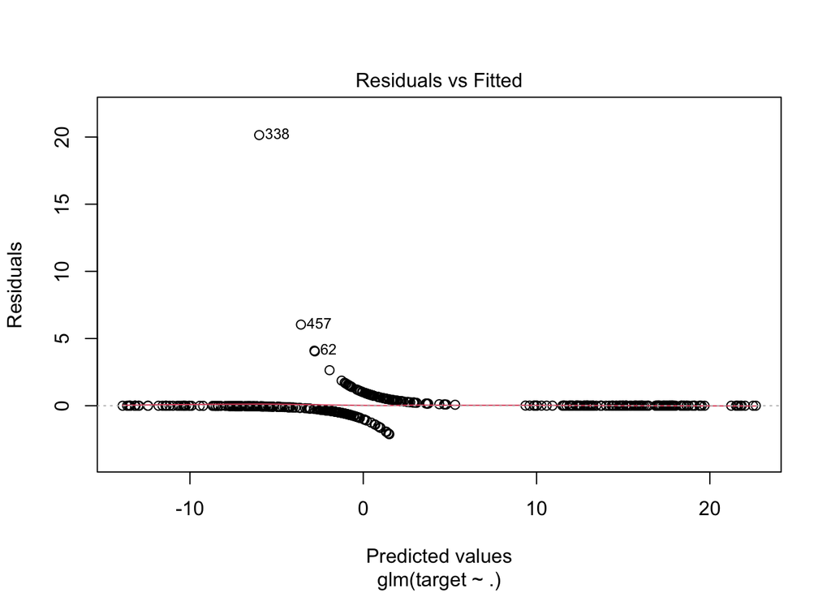

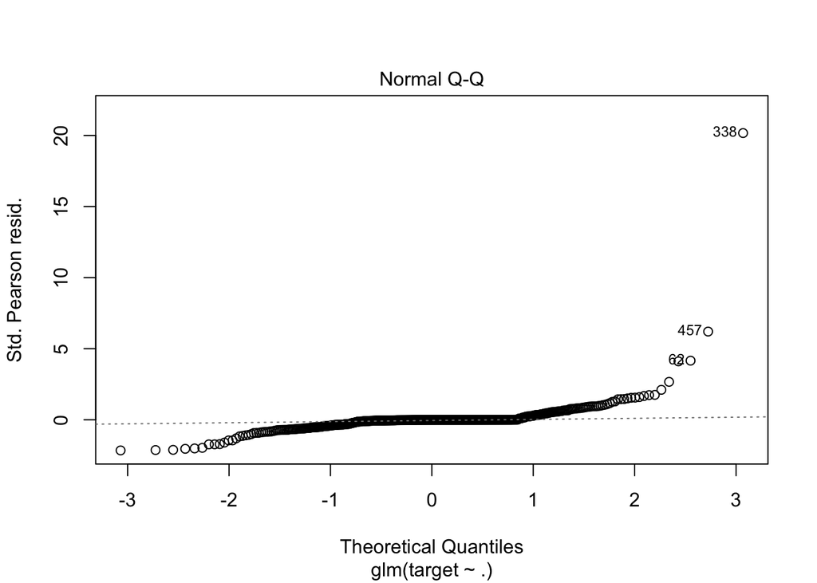

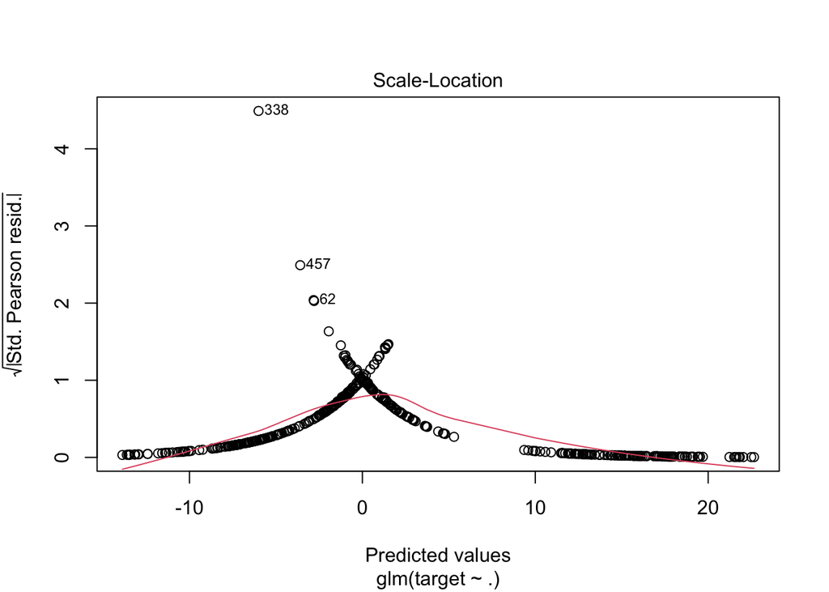

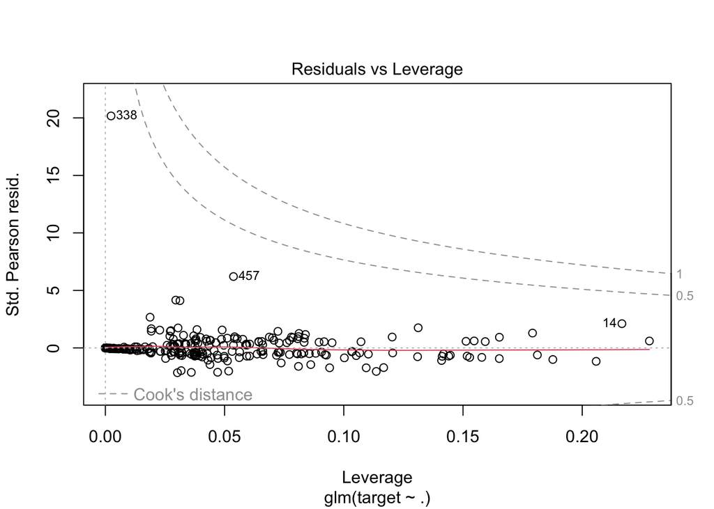

```r
plot(crime_binary_model_1)
```

### Model 2

The second data set is based on the log transformation on skewed variables.

```r
crime_binary_model_2 <- glm(crime_training_data_transformed, family = 'binomial', formula = target ~.)
summary(crime_binary_model_2)
```

```
##
## Call:
## glm(formula = target ~ ., family = "binomial", data = crime_training_data_transformed)
##
## Deviance Residuals:
##     Min       1Q   Median       3Q      Max
## -1.9524  -0.1598  -0.0010   0.0007   3.5250
##
## Coefficients:
##                                        Estimate Std. Error z value Pr(>|z|)
## (Intercept)                          -4.557e+01  9.945e+00  -4.582 4.60e-06 ***
## zn                                    2.221e-04  2.941e-02   0.008 0.993976
## indus                                 8.180e-04  5.799e-02   0.014 0.988745
## chas                                  5.920e-01  7.979e-01   0.742 0.458136
## nox                                   6.105e+01  9.089e+00   6.716 1.86e-11 ***
## rm                                   -1.629e+00  8.663e-01  -1.880 0.060057 .
## age                                   1.397e-01  3.379e-02   4.134 3.57e-05 ***
## dis                                  -3.372e+00  1.118e+00  -3.017 0.002553 **
## rad                                   8.869e-01  2.024e-01   4.382 1.18e-05 ***
## tax                                  -6.344e-03  3.174e-03  -1.999 0.045659 *
## ptratio                               5.624e-01  1.488e-01   3.779 0.000157 ***
## lstat                                 1.790e-01  1.477e-01   1.212 0.225587
## medv                                  2.384e-01  8.428e-02   2.829 0.004670 **
## `log(crime_training_data$age + 1)`   -4.835e+00  1.289e+00  -3.750 0.000177 ***
## `log(crime_training_data$dis + 1)`    2.152e+01  5.855e+00   3.676 0.000237 ***
## `log(crime_training_data$lstat + 1)` -2.903e+00  2.118e+00  -1.370 0.170543
## ---
## Signif. codes:  0 '***' 0.001 '**' 0.01 '*' 0.05 '.' 0.1 ' ' 1
##
## (Dispersion parameter for binomial family taken to be 1)
##
##     Null deviance: 645.88  on 465  degrees of freedom
## Residual deviance: 166.99  on 450  degrees of freedom
## AIC: 198.99
##
## Number of Fisher Scoring iterations: 9
```

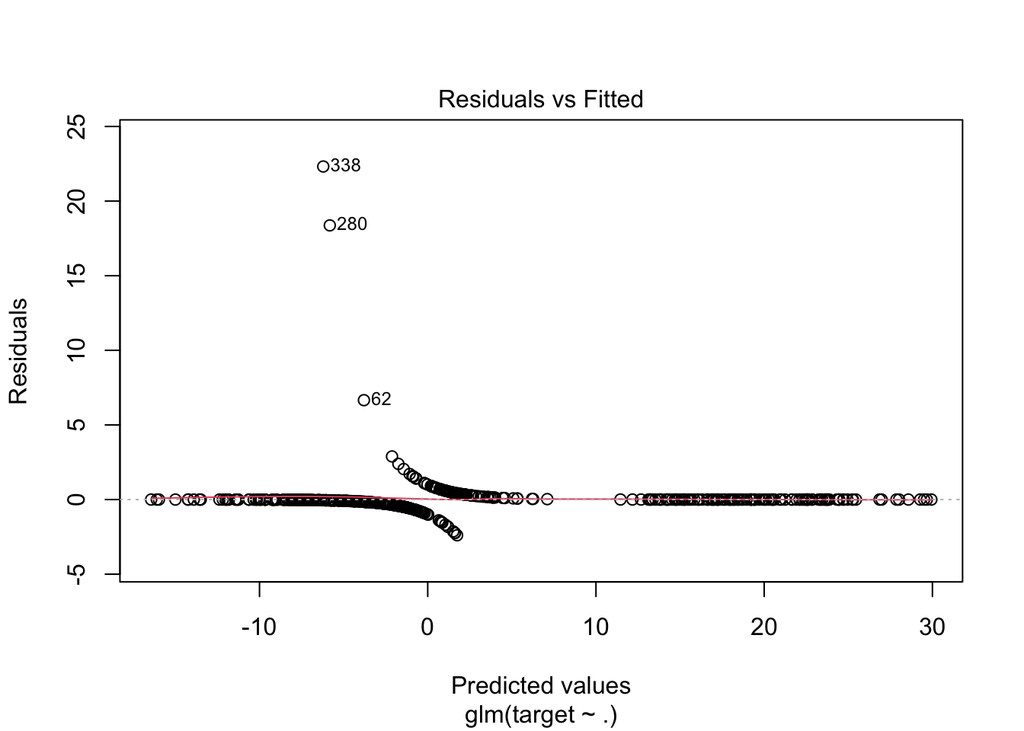

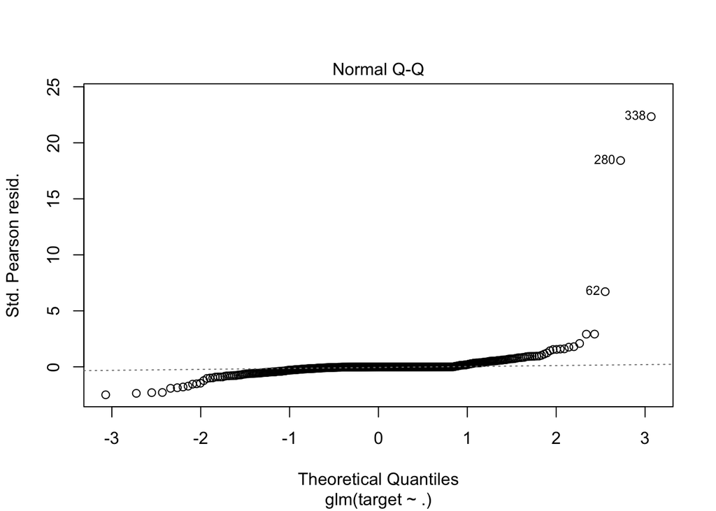

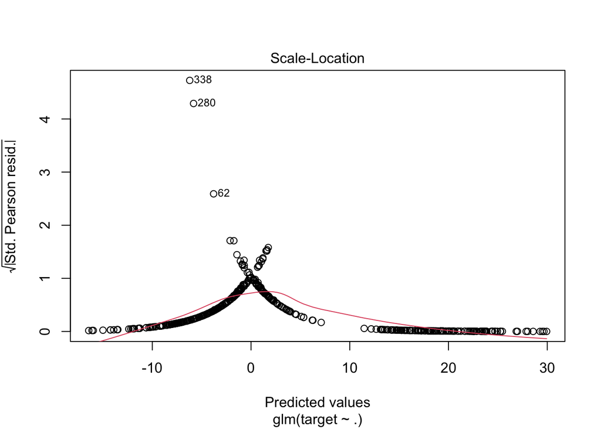

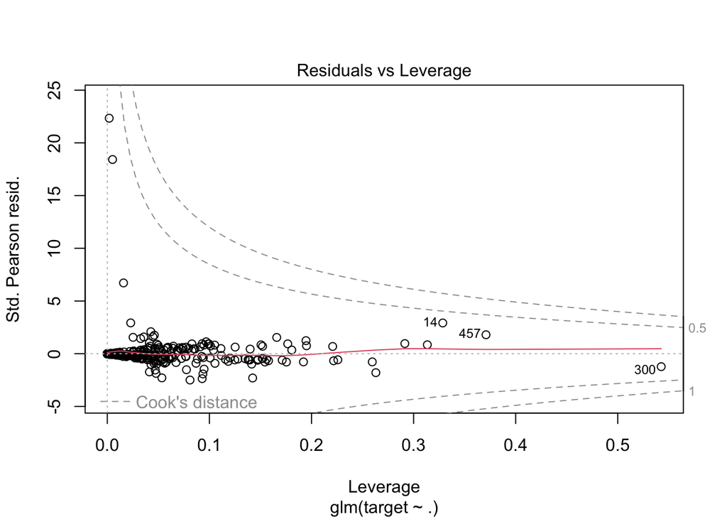

```r
plot(crime_binary_model_2)
```

### Model 3

The third data set is based on the `tax` variable being removed.

```r
crime_binary_model_3 <- glm(crime_training_data_tax_removed, family = 'binomial', formula = target ~.)
summary(crime_binary_model_3)
```

```
##
## Call:
## glm(formula = target ~ ., family = "binomial", data = crime_training_data_tax_removed)
##
## Deviance Residuals:
##     Min       1Q   Median       3Q      Max
## -1.8743  -0.1768  -0.0026   0.0055   3.5405
##
## Coefficients:
##              Estimate Std. Error z value Pr(>|z|)
## (Intercept) -41.17734    6.56537  -6.272 3.57e-10 ***
## zn           -0.07141    0.03499  -2.041 0.041293 *
## indus        -0.11249    0.04529  -2.484 0.013001 *
## chas          1.25335    0.72930   1.719 0.085693 .
## nox          49.11180    7.90647   6.212 5.24e-10 ***
## rm           -0.69362    0.69760  -0.994 0.320076
## age           0.03471    0.01362   2.548 0.010828 *
## dis           0.83505    0.22671   3.683 0.000230 ***
## rad           0.50619    0.13392   3.780 0.000157 ***
## ptratio       0.38009    0.12180   3.121 0.001805 **
## lstat         0.03387    0.05318   0.637 0.524112
## medv          0.19946    0.06592   3.026 0.002479 **
## ---
## Signif. codes:  0 '***' 0.001 '**' 0.01 '*' 0.05 '.' 0.1 ' ' 1
##
## (Dispersion parameter for binomial family taken to be 1)
##
##     Null deviance: 645.88  on 465  degrees of freedom
## Residual deviance: 196.59  on 454  degrees of freedom
## AIC: 220.59
##
## Number of Fisher Scoring iterations: 9
```

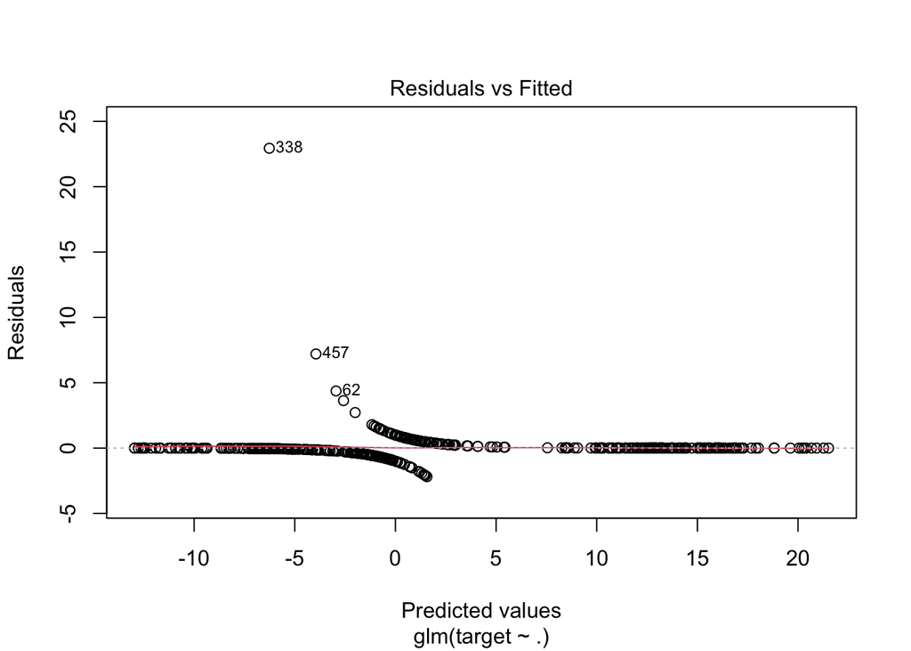

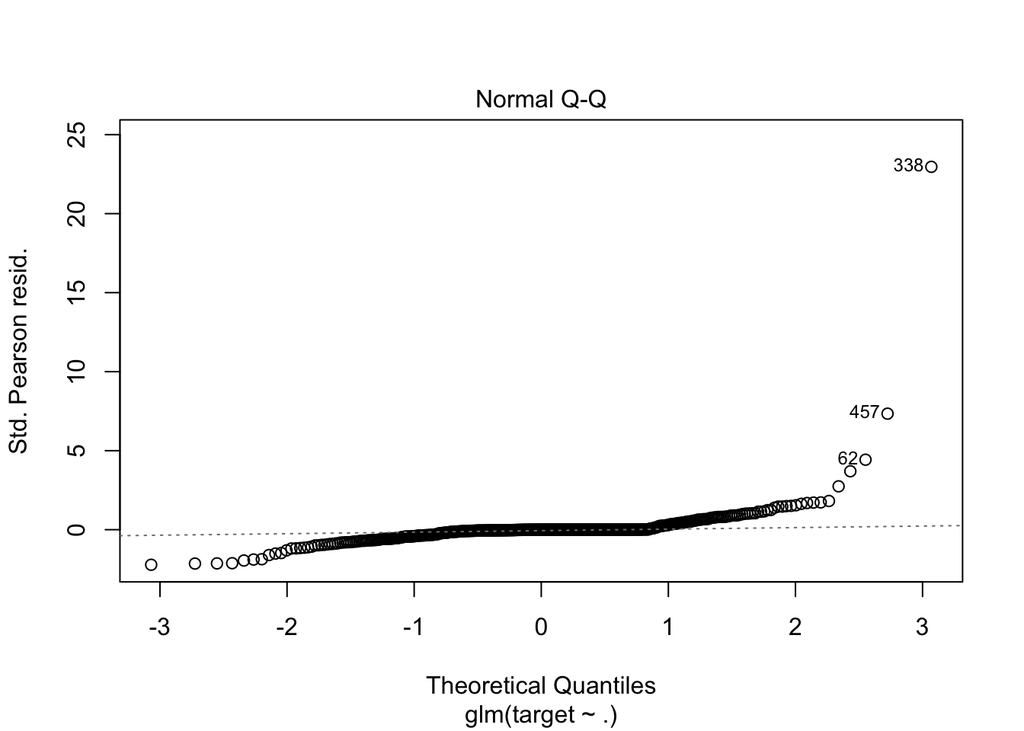

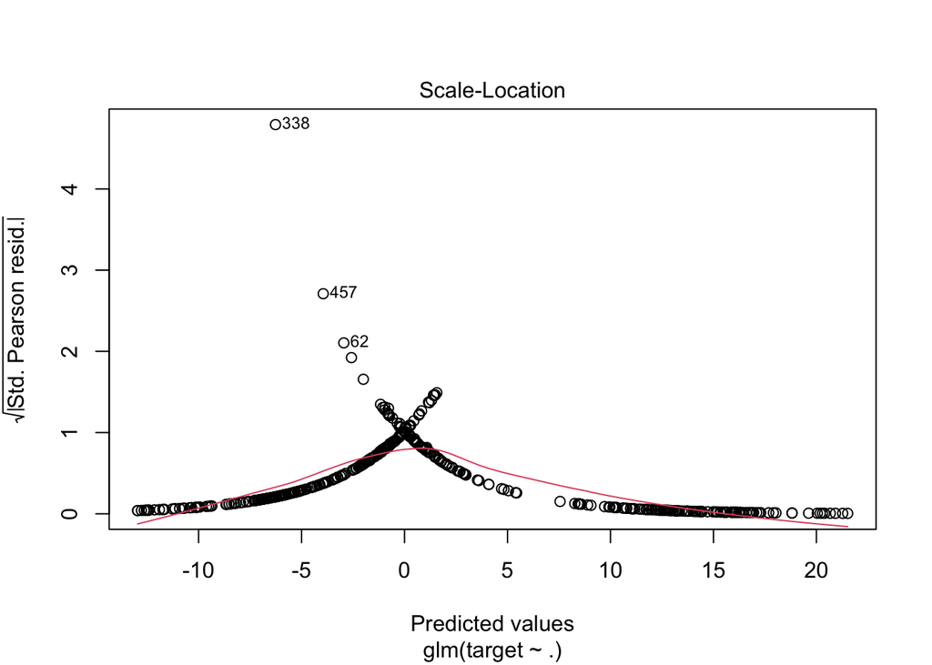

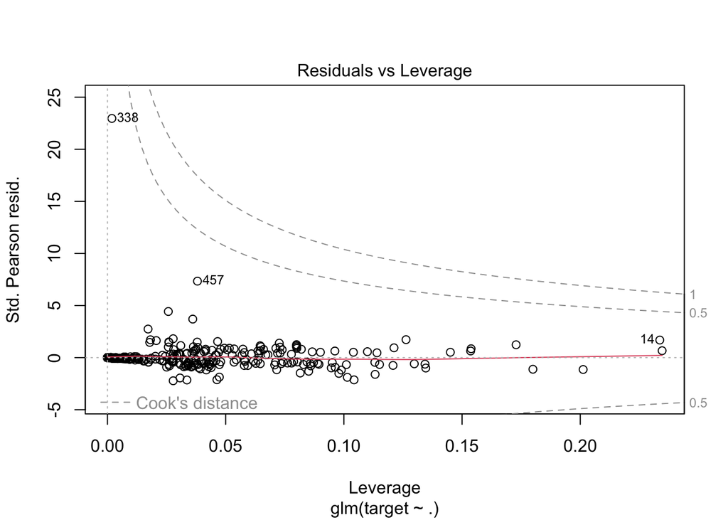

```r
plot(crime_binary_model_3)
```

### Model 4

The dataset will be based on rows removed due to them being outliers on `tax` and `rad` variables.

```r
crime_binary_model_4 <- glm(crime_training_data_updated, family = 'binomial', formula = target ~.)
summary(crime_binary_model_4)
```

```
##
## Call:
## glm(formula = target ~ ., family = "binomial", data = crime_training_data_updated)
##
## Deviance Residuals:
##     Min       1Q   Median       3Q      Max
## -1.8463  -0.4579  -0.0406   0.2160   3.4664
##
## Coefficients:
##               Estimate Std. Error z value Pr(>|z|)
## (Intercept) -40.820514   6.633373  -6.154 7.56e-10 ***
## zn           -0.065939   0.034657  -1.903  0.05709 .
## indus        -0.064635   0.047631  -1.357  0.17478
## chas          0.910981   0.755549   1.206  0.22793
## nox          49.120624   7.931765   6.193 5.91e-10 ***
## rm           -0.587298   0.722866  -0.812  0.41653
## age           0.034186   0.013814   2.475  0.01333 *
## dis           0.738646   0.230269   3.208  0.00134 **
## rad           0.666121   0.163466   4.075 4.60e-05 ***
## tax          -0.006170   0.002955  -2.088  0.03681 *
## ptratio       0.402506   0.126647   3.178  0.00148 **
## lstat         0.045867   0.054047   0.849  0.39608
## medv          0.180806   0.068294   2.647  0.00811 **
## ---
## Signif. codes:  0 '***' 0.001 '**' 0.01 '*' 0.05 '.' 0.1 ' ' 1
##
## (Dispersion parameter for binomial family taken to be 1)
##
##     Null deviance: 428.84  on 344  degrees of freedom
## Residual deviance: 192.05  on 332  degrees of freedom
## AIC: 218.05
##
## Number of Fisher Scoring iterations: 8
```

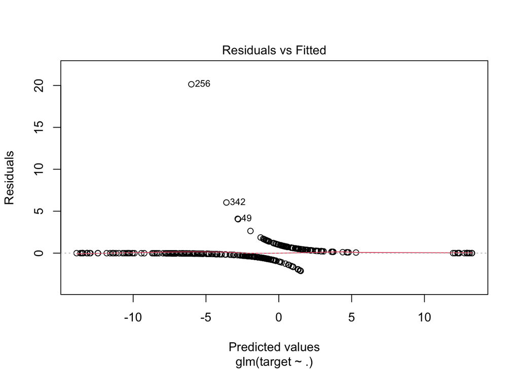

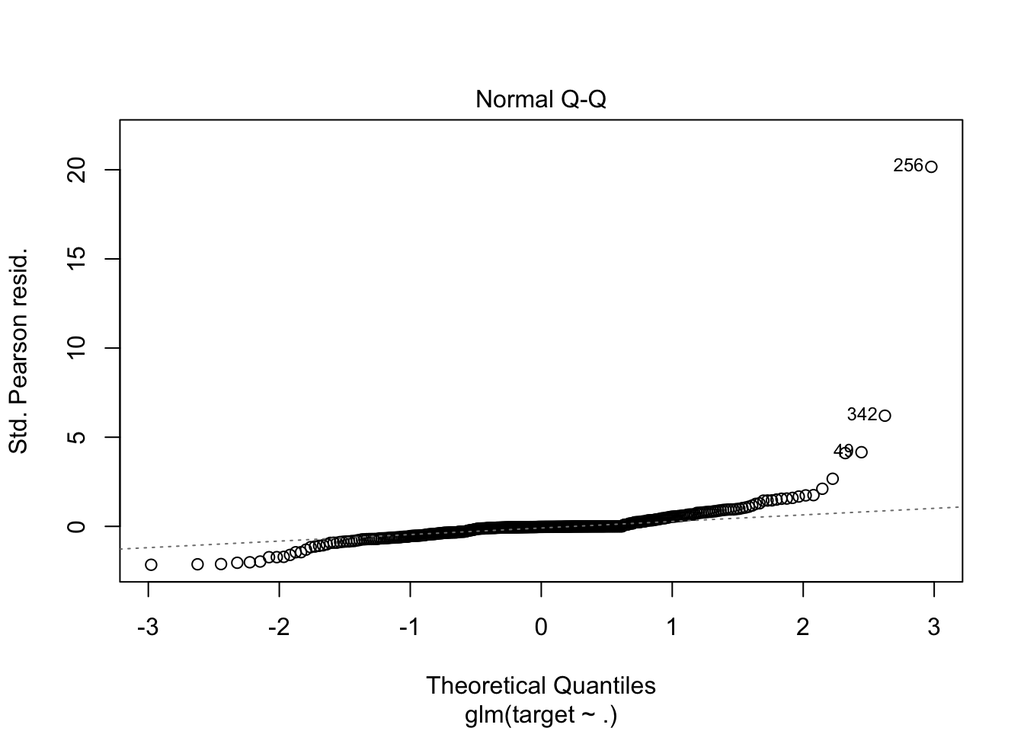

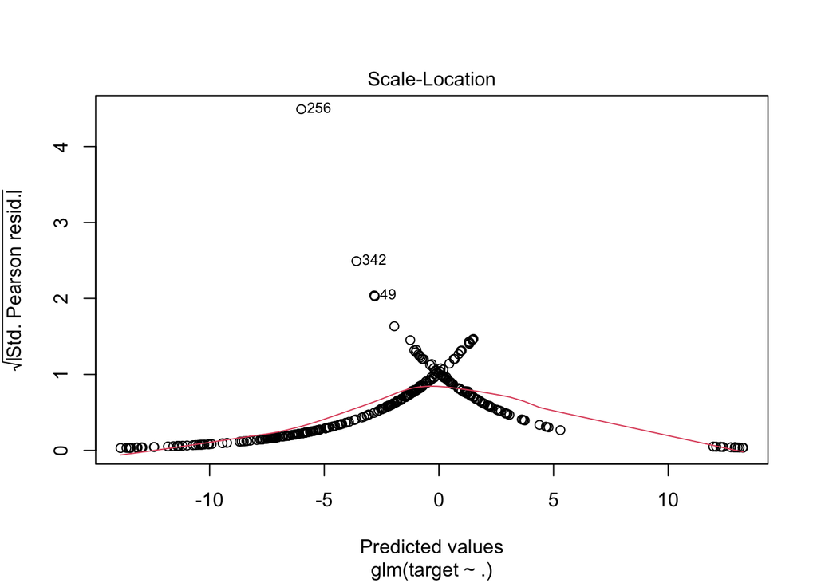

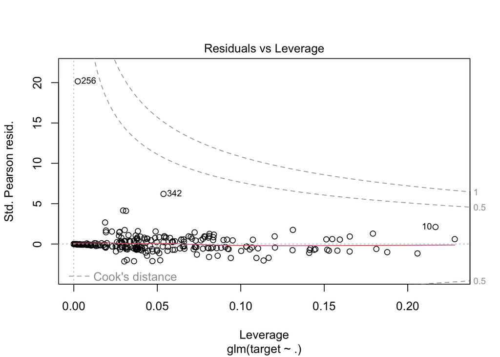

```r
plot(crime_binary_model_4)
```

## Select Model

*Decide on the criteria for selecting the best binary logistic regression model. Will you select models with slightly worse performance if it makes more sense or is more parsimonious? Discuss why you selected your model.*

### Model 1 Assessment

```r
data_split_model_1 <- createDataPartition(y = crime_training_data$target, p = 0.8, list = FALSE)
crime_train_data_model_1 <- crime_training_data[data_split_model_1,]
crime_test_data_model_1 <- crime_training_data[-data_split_model_1,]
crime_binary_test_model_1 <- glm(crime_train_data_model_1, family = 'binomial', formula = target ~.)
crime_binary_prediction_1 <- predict(crime_binary_test_model_1, crime_test_data_model_1, type = "response")
crime_predicted_class_1 <- ifelse(crime_binary_prediction_1 > 0.5, 1, 0)
crime_confusion_matrix_1 <- confusionMatrix(data = as.factor(crime_predicted_class_1), reference = as.factor(crime_test_data_model_1$target))

print(crime_confusion_matrix_1)
```

```
## Confusion Matrix and Statistics
##
##           Reference
## Prediction  0  1
##          0 38  5
##          1  1 49
##
##                Accuracy : 0.9355
##                  95% CI : (0.8648, 0.976)
##     No Information Rate : 0.5806
##     P-Value [Acc > NIR] : 1.319e-14
##
##                   Kappa : 0.8694
##
##  Mcnemar's Test P-Value : 0.2207
##
##             Sensitivity : 0.9744
##             Specificity : 0.9074
##          Pos Pred Value : 0.8837
##          Neg Pred Value : 0.9800
##              Prevalence : 0.4194
##          Detection Rate : 0.4086
##    Detection Prevalence : 0.4624
##       Balanced Accuracy : 0.9409
##
##        'Positive' Class : 0
##
```

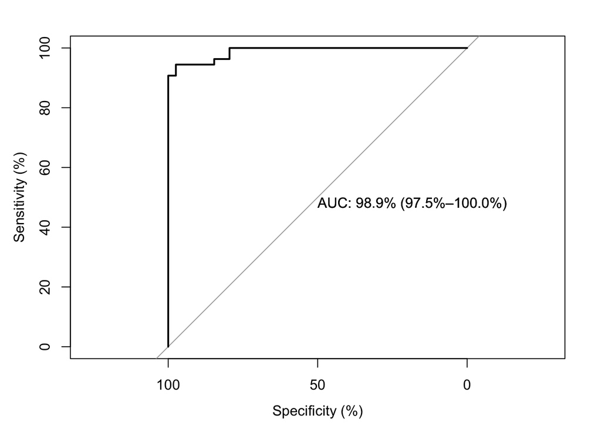

```
##
## Call:
## roc.default(response = crime_test_data_model_1$target, predictor = crime_binary_prediction_1,     percent = TRUE, ci = TRUE, plot = TRUE, print.auc = TRUE)
##
## Data: crime_binary_prediction_1 in 39 controls (crime_test_data_model_1$target 0) < 54 cases (crime_test_data_model_1$target 1).
## Area under the curve: 98.86%
## 95% CI: 97.47%-100% (DeLong)
```

```r
roc(crime_test_data_model_1$target, crime_binary_prediction_1 , percent=TRUE, plot=TRUE, ci=TRUE, print.auc = TRUE)
```

### Model 2 Assessment

```r
data_split_model_2 <- createDataPartition(y = crime_training_data_transformed$target, p = 0.8, list = FALSE)
crime_train_data_model_2 <- crime_training_data_transformed[data_split_model_2,]
crime_test_data_model_2 <- crime_training_data_transformed[-data_split_model_2,]
crime_binary_test_model_2 <- glm(crime_train_data_model_2, family = 'binomial', formula = target ~.)
crime_binary_prediction_2 <- predict(crime_binary_test_model_2, crime_test_data_model_2, type = "response")
crime_predicted_class_2 <- ifelse(crime_binary_prediction_2 > 0.5, 1, 0)
crime_confusion_matrix_2 <- confusionMatrix(data = as.factor(crime_predicted_class_2), reference = as.factor(crime_test_data_model_2$target))

print(crime_confusion_matrix_2)
```

```
## Confusion Matrix and Statistics
##
##           Reference
## Prediction  0  1
##          0 44  3
##          1  4 42
##
##                Accuracy : 0.9247
##                  95% CI : (0.851, 0.9692)
##     No Information Rate : 0.5161
##     P-Value [Acc > NIR] : <2e-16
##
##                   Kappa : 0.8494
##
##  Mcnemar's Test P-Value : 1
##
##             Sensitivity : 0.9167
##             Specificity : 0.9333
##          Pos Pred Value : 0.9362
##          Neg Pred Value : 0.9130
##              Prevalence : 0.5161
##          Detection Rate : 0.4731
##    Detection Prevalence : 0.5054
##       Balanced Accuracy : 0.9250
##
##        'Positive' Class : 0
##
```

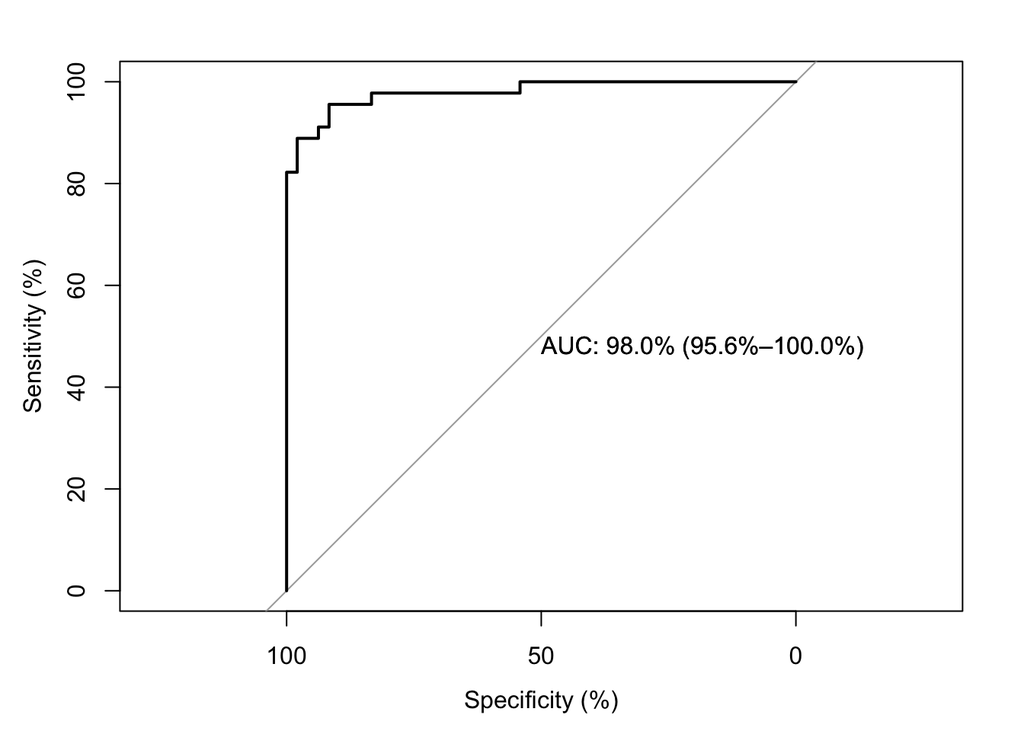

```
##
## Call:
## roc.default(response = crime_test_data_model_2$target, predictor = crime_binary_prediction_2,     percent = TRUE, ci = TRUE, plot = TRUE, print.auc = TRUE)
##
## Data: crime_binary_prediction_2 in 48 controls (crime_test_data_model_2$target 0) < 45 cases (crime_test_data_model_2$target 1).
## Area under the curve: 97.96%
## 95% CI: 95.59%-100% (DeLong)
```

```r
roc(crime_test_data_model_2$target, crime_binary_prediction_2, percent=TRUE, plot=TRUE, ci=TRUE, print.auc = TRUE)
```

### Model 3 Assessment

```r
data_split_model_3 <- createDataPartition(y = crime_training_data_tax_removed$target, p = 0.8, list = FALSE)
crime_train_data_model_3 <- crime_training_data_tax_removed[data_split_model_3,]
crime_test_data_model_3 <- crime_training_data_tax_removed[-data_split_model_3,]
crime_binary_test_model_3 <- glm(crime_train_data_model_3, family = 'binomial', formula = target ~.)
crime_binary_prediction_3 <- predict(crime_binary_test_model_3, crime_test_data_model_3, type = "response")
crime_predicted_class_3 <- ifelse(crime_binary_prediction_3 > 0.5, 1, 0)
crime_confusion_matrix_3 <- confusionMatrix(data = as.factor(crime_predicted_class_3), reference = as.factor(crime_test_data_model_3$target))

print(crime_confusion_matrix_3)
```

```
## Confusion Matrix and Statistics
##
##           Reference
## Prediction  0  1
##          0 45  7
##          1  1 40
##
##                Accuracy : 0.914
##                  95% CI : (0.8375, 0.9621)
##     No Information Rate : 0.5054
##     P-Value [Acc > NIR] : <2e-16
##
##                   Kappa : 0.8282
##
##  Mcnemar's Test P-Value : 0.0771
##
##             Sensitivity : 0.9783
##             Specificity : 0.8511
##          Pos Pred Value : 0.8654
##          Neg Pred Value : 0.9756
##              Prevalence : 0.4946
##          Detection Rate : 0.4839
##    Detection Prevalence : 0.5591
##       Balanced Accuracy : 0.9147
##
##        'Positive' Class : 0
##
```

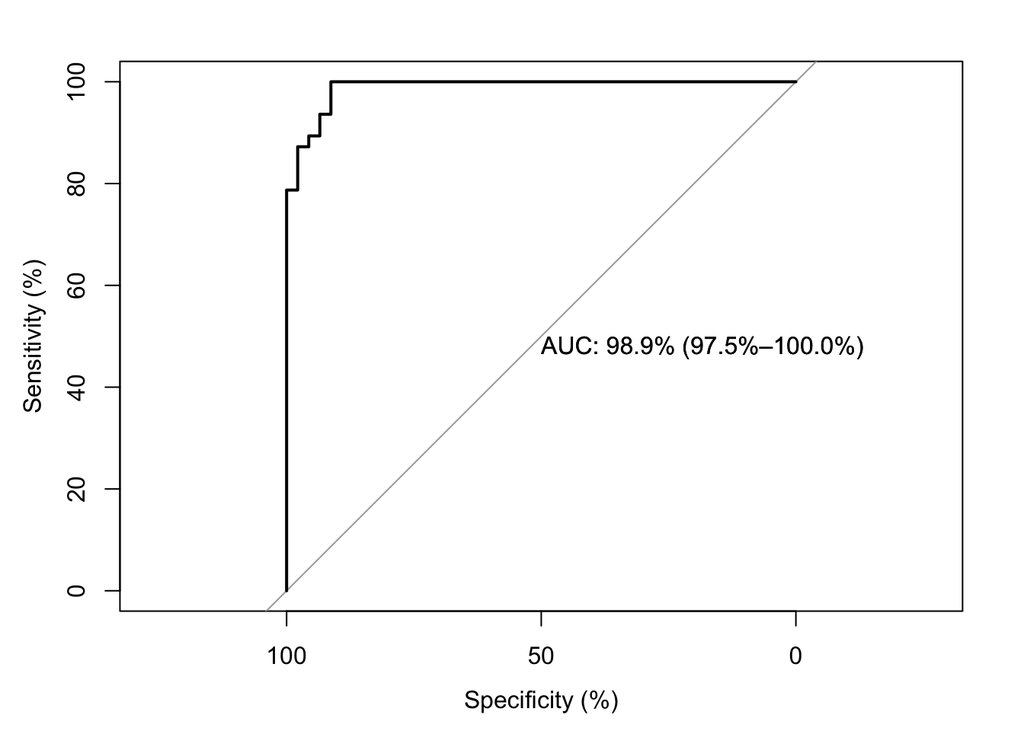

```
##
## Call:
## roc.default(response = crime_test_data_model_3$target, predictor = crime_binary_prediction_3,     percent = TRUE, ci = TRUE, plot = TRUE, print.auc = TRUE)
##
## Data: crime_binary_prediction_3 in 46 controls (crime_test_data_model_3$target 0) < 47 cases (crime_test_data_model_3$target 1).
## Area under the curve: 98.89%
## 95% CI: 97.53%-100% (DeLong)
```

```r
roc(crime_test_data_model_3$target, crime_binary_prediction_3, percent=TRUE, plot=TRUE, ci=TRUE, print.auc = TRUE)
```

### Model 4 Assessment

```r
data_split_model_4 <- createDataPartition(y = crime_training_data_updated$target, p = 0.8, list = FALSE)
crime_train_data_model_4 <- crime_training_data_updated[data_split_model_4,]
crime_test_data_model_4 <- crime_training_data_updated[-data_split_model_4,]
crime_binary_test_model_4 <- glm(crime_train_data_model_4, family = 'binomial', formula = target ~.)
crime_binary_prediction_4 <- predict(crime_binary_test_model_4, crime_test_data_model_4, type = "response")
crime_predicted_class_4 <- ifelse(crime_binary_prediction_4 > 0.5, 1, 0)
crime_confusion_matrix_4 <- confusionMatrix(data = as.factor(crime_predicted_class_4), reference = as.factor(crime_test_data_model_4$target))

print(crime_confusion_matrix_4)
```

```
## Confusion Matrix and Statistics
##
##           Reference
## Prediction  0  1
##          0 42  9
##          1  1 17
##
##                Accuracy : 0.8551
##                  95% CI : (0.7496, 0.9283)
##     No Information Rate : 0.6232
##     P-Value [Acc > NIR] : 2.037e-05
##
##                   Kappa : 0.6714
##
##  Mcnemar's Test P-Value : 0.02686
##
##             Sensitivity : 0.9767
##             Specificity : 0.6538
##          Pos Pred Value : 0.8235
##          Neg Pred Value : 0.9444
##              Prevalence : 0.6232
##          Detection Rate : 0.6087
##    Detection Prevalence : 0.7391
##       Balanced Accuracy : 0.8153
##
##        'Positive' Class : 0
##
```

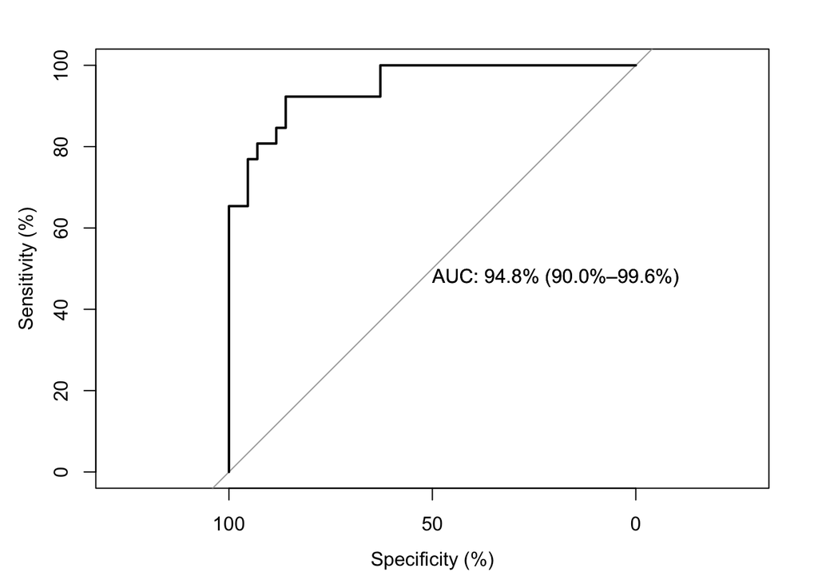

```
##
## Call:
## roc.default(response = crime_test_data_model_4$target, predictor = crime_binary_prediction_4,     percent = TRUE, ci = TRUE, plot = TRUE, print.auc = TRUE)
##
## Data: crime_binary_prediction_4 in 43 controls (crime_test_data_model_4$target 0) < 26 cases (crime_test_data_model_4$target 1).
## Area under the curve: 94.81%
## 95% CI: 90.01%-99.62% (DeLong)
```

```r
roc(crime_test_data_model_4$target, crime_binary_prediction_4, percent=TRUE, plot=TRUE, ci=TRUE, print.auc = TRUE)
```

## References

- [Primer on binary logistic regression](https://www.ncbi.nlm.nih.gov/pmc/articles/PMC8710907/)
- [R-Blogger: Evaluating Logistic Regression Model](https://www.r-bloggers.com/2015/08/evaluating-logistic-regression-models/#google_vignette)